# Exploring Stoet & Geary (2018) and Falk and Hermle (2018) data

Molly Lewis and Gary Lupyan

2019-05-27

Here are the key claims in the two papers:

**STOET AND GEARY (2018) CLAIM**: At the individual level, boys tend to be *relatively* better STEM than girls. This generally leads boys to be more likely to pursue STEM jobs. But, by expectancy value theory, when there’s less economic opportunity, girls are more likely to go against their relative strengths and pursue STEM degrees (because STEM jobs are high paying). As a result, in countries with less economic opporunity there are more girls pursuing STEM jobs, and thus more STEM equality.

- Key measure: `self_efficacy_diff` (“The sex difference in self efficacy (boys – girls)”)
- Result with respect to language bias: Language bias and STEM are correlated. The effect is mediated by differences in self efficacy, suggesting that language bias leads to differences in self-efficacy (language -> self efficacy -> STEM). This also holds for the wikipedia model. Also holds for three other meaasures of gender inequality (hdi, gini, ggi).

**FALK AND HERMLE (2018) CLAIM**: Boys and girls have different preferences. When there’s more economic opportunity (GDP), people are more free to express their preferences, leading to greater divergence in gender preferences in countries lots of economic opportunity.

## Correlations between all measures at the country level

```r
# get GDP 2017 data from World Bank API
gdp_data <- wbstats::wb(indicator = "NY.GDP.PCAP.CD",
                        startdate = 2017,
                        enddate = 2017) %>%
            select(iso2c, value) %>%
            rename(gdp_2017 = value)

FALK_PATH <- here("data/other/falk_hermle_2018_data.dta")
pref_data <- read.dta13(FALK_PATH) %>%
  mutate(country_code = countrycode::countrycode(ison, "iso3n", "iso2c")) %>%
  select(country_code, genderdif)

#pref_data2 <- readstata13::read.dta13("/Users/mollylewis/Downloads/GPS_dataset_country_level/country.dta") %>%
#  mutate(country_code = countrycode::countrycode(ison, #"iso3n", "iso2c")) %>%
 # select(country_code, genderdif)

STOET_PATH <- "/Users/mollylewis/Documents/research/Projects/1_in_progress/IATLANG/exploratory_studies/7_age_controls/stoet_data.csv"
stoet_data <- read_csv(STOET_PATH) %>%
  mutate(country_code = countrycode::countrycode(country_name, "country.name", "iso2c")) %>%
  select(country_code, everything())

# data from Bill von Hippel
INPATH <- "data/Molly data2.csv"
country_raw <- read_csv(INPATH) %>%
  janitor::clean_names()  %>%
  left_join(gdp_data, by = c("country_code" = "iso2c"))   %>%
  left_join(stoet_data) %>%
  left_join(pref_data)

# save country data with GDP 2017 data merged in (unscaled)
# OUTPATH <- "country_level_data_with_GDP.csv"
# write_csv(country_raw, OUTPATH)

# scale variables
country_level <- country_raw %>%
  mutate_if(is.numeric, base::scale)
```

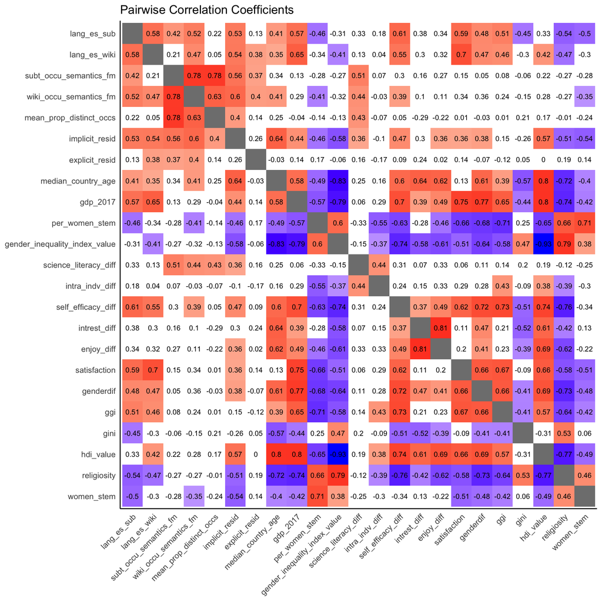

Pairwise correlation between all country-level measures. Red and blue correspond to positive and negative correlations, respectively. Non-significant correlations ( >= .05) are indicated with white squares.

```r
plot_data <- country_level %>%
  select_if(is.numeric) %>%
  select(-n_participants, -gdp_2013)

long_corr <- cor(plot_data,
                use = "pairwise.complete.obs") %>%
  as.data.frame() %>%
  rownames_to_column("v2") %>%
  gather("v1", "estimate", -v2)

long_p <- corrplot::cor.mtest(plot_data,
                             use = "pairwise.complete.obs")$p %>%
  as.data.frame(row.names = names(plot_data)) %>%
  do(setNames(.,names(plot_data))) %>%
      rownames_to_column("v2") %>%
  gather("v1", "p", -v2)

corr_df <- full_join(long_corr, long_p) %>%
  mutate(estimate_char = case_when(v1 == v2 ~ "",
                              TRUE ~ as.character(round(estimate,2))),
         estimate = case_when(v1 == v2 ~ as.numeric(NA),
                              TRUE ~ estimate),
         estimate_color = case_when(p < .05 ~ estimate, TRUE ~ 0),
         v1 = fct_relevel(v1, "lang_es_sub", "lang_es_wiki", "subt_occu_semantics_fm",
                          "wiki_occu_semantics_fm", "mean_prop_distinct_occs", "implicit_resid", "explicit_resid", "median_country_age", "gdp_2017", "per_women_stem", "gender_inequality_index_value", "science_literacy_diff", "intra_indv_diff", "self_efficacy_diff", "intrest_diff", "enjoy_diff", "satisfaction"),
           v2 = fct_relevel(v2, "lang_es_sub", "lang_es_wiki", "subt_occu_semantics_fm",
                          "wiki_occu_semantics_fm", "mean_prop_distinct_occs", "implicit_resid", "explicit_resid", "median_country_age", "gdp_2017", "per_women_stem", "gender_inequality_index_value", "science_literacy_diff", "intra_indv_diff", "self_efficacy_diff", "intrest_diff", "enjoy_diff","satisfaction"))

ggplot(corr_df, aes(v1, fct_rev(v2), fill = estimate_color)) +
  geom_tile() + #rectangles for each correlation
  #add actual correlation value in the rectangle
  geom_text(aes(label = estimate_char), size = 3) +
  scale_fill_gradient2(low ="blue", mid = "white", high = "red",
                       midpoint = 0, space = "Lab", guide = "colourbar",
                       name = "Pearson's r") +
  ggtitle("Pairwise Correlation Coefficients") +
  theme_classic(base_size = 12) +
  theme(axis.text.x = element_text(angle = 45, hjust = 1), #, hjust = .95, vjust = .2),
        axis.title.x = element_blank(),
        axis.title.y = element_blank(),
        axis.ticks = element_blank(),
        legend.position = "none")
```

## STEM Self Efficacy Gender Difference (Stoet & Geary, 2018)

Note that this is with their measure (per_women_stem); the mediation isn’t siginficant with our women stem measure…not clear why, other than that the data is newer.

### Target correlations

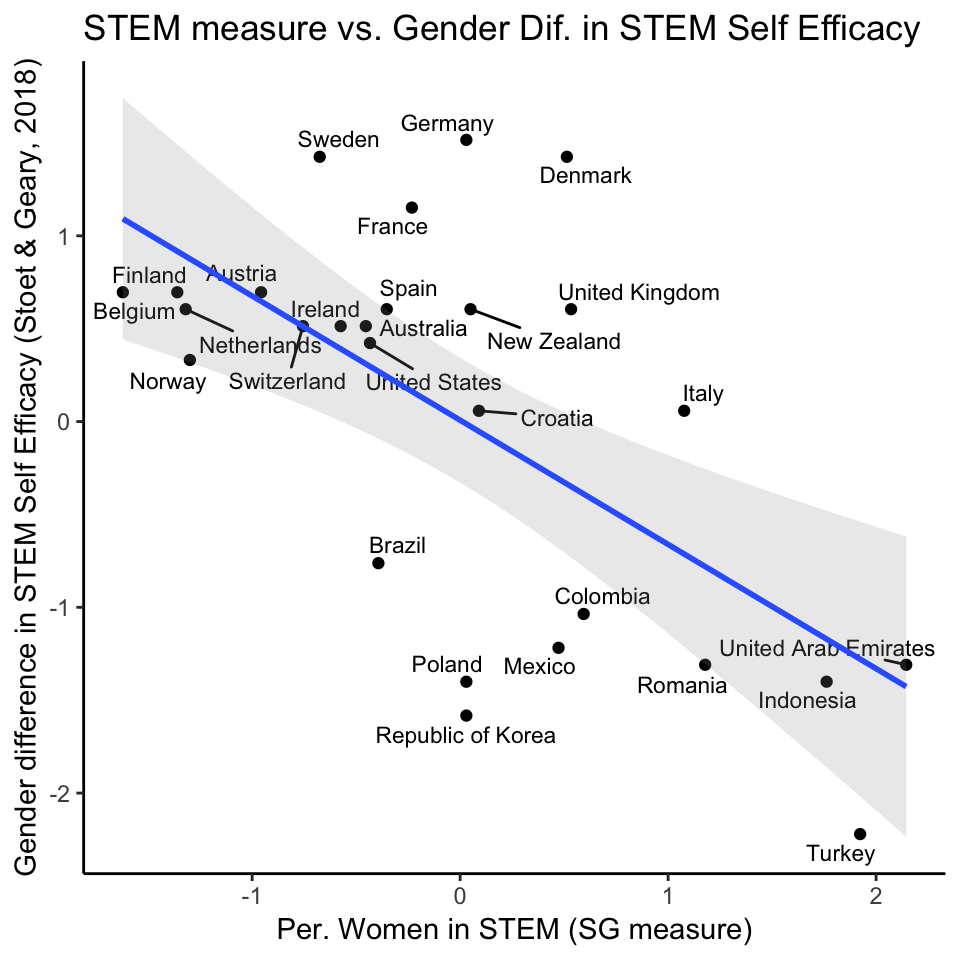

```r
country_level %>%
  ggplot(aes(x = per_women_stem, y = self_efficacy_diff, label = country))+
  geom_point() +
  geom_text_repel(size = 3) +
  ylab("Gender difference in STEM Self Efficacy (Stoet & Geary, 2018)") +
  xlab("Per. Women in STEM (SG measure)") +
  ggtitle("STEM measure vs. Gender Dif. in STEM Self Efficacy  ") +
  geom_smooth(method = "lm", alpha = .2) +
  theme_classic()
```

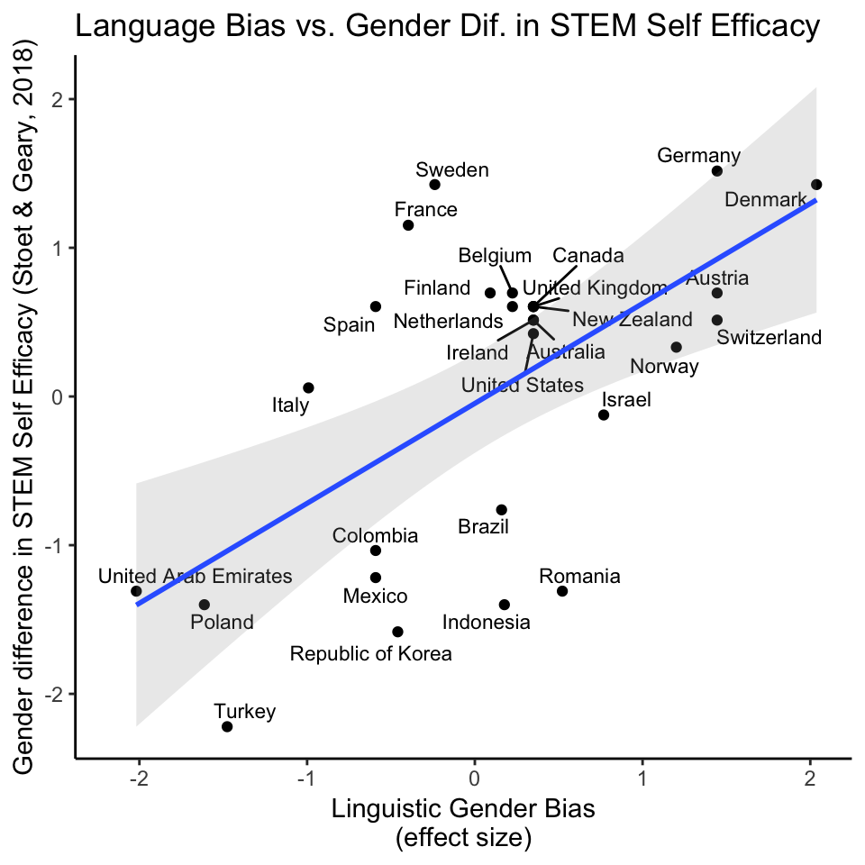

```r
country_level %>%
  ggplot(aes(x = lang_es_sub, y = self_efficacy_diff, label = country))+
  geom_point() +
  geom_text_repel(size = 3) +
  ylab("Gender difference in STEM Self Efficacy (Stoet & Geary, 2018)") +
  xlab("Linguistic Gender Bias\n(effect size)") +
  ggtitle("Language Bias vs. Gender Dif. in STEM Self Efficacy  ") +
  geom_smooth(method = "lm", alpha = .2) +
  theme_classic()
```

### Regressions

```r
lm(per_women_stem ~ self_efficacy_diff + lang_es_sub, data = country_level) %>%
  summary()
```

```
##
## Call:
## lm(formula = per_women_stem ~ self_efficacy_diff + lang_es_sub,
##     data = country_level)
##
## Residuals:
##     Min      1Q  Median      3Q     Max
## -1.2426 -0.6839 -0.1395  0.5759  1.5049
##
## Coefficients:
##                     Estimate Std. Error t value Pr(>|t|)
## (Intercept)         0.008111   0.161698   0.050   0.9604
## self_efficacy_diff -0.514323   0.191907  -2.680   0.0134 *
## lang_es_sub        -0.130940   0.212744  -0.615   0.5443
## ---
## Signif. codes:  0 '***' 0.001 '**' 0.01 '*' 0.05 '.' 0.1 ' ' 1
##
## Residual standard error: 0.8215 on 23 degrees of freedom
##   (13 observations deleted due to missingness)
## Multiple R-squared:  0.4027, Adjusted R-squared:  0.3508
## F-statistic: 7.755 on 2 and 23 DF,  p-value: 0.002666
```

### Mediation Models

```r
#psych::mediate(x = "lang_es_sub", y = "per_women_stem", m = "self_efficacy_diff",
#               data = country_level, plot = T) %>%
#  summary()

country_level %>%
  fit_mediation(
    x = "lang_es_sub",
    y = "per_women_stem",
    m = "self_efficacy_diff") %>%
   test_mediation() %>%
   p_value()
```

```
## [1] 0.0108
```

This also holds for the wikipedia model. Also holds for three other meaasures of gender inequality (hdi, gini, ggi)

```r
#psych::mediate(x = "lang_es_sub", y = "intra_indv_diff", m = "self_efficacy_diff",
#               data = country_level, plot = T) %>%
#  summary()

country_level %>%
  fit_mediation(
    x = "lang_es_sub",
    y = "intra_indv_diff",
    m = "self_efficacy_diff") %>%
   test_mediation() %>%
   p_value()
```

```
## [1] 0.3691
```

## Composite Preference Differences (Falk & Hermle, 2018)

### Target correlations

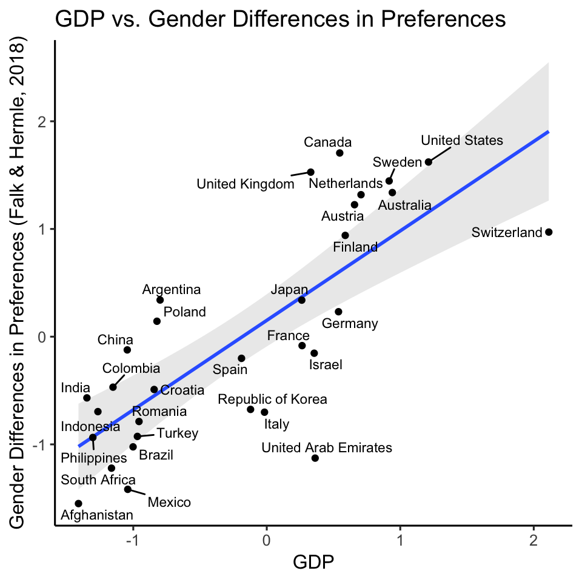

```r
country_level %>%
  ggplot(aes(x = gdp_2017, y = genderdif, label = country))+
  ylab("Gender Differences in Preferences (Falk & Hermle, 2018)") +
  xlab("GDP") +
  ggtitle("GDP vs. Gender Differences in Preferences ") +
  geom_smooth(method = "lm", alpha = .2) +
  geom_point() +
  geom_text_repel(size = 3) +
  theme_classic(base_size = 12)
```

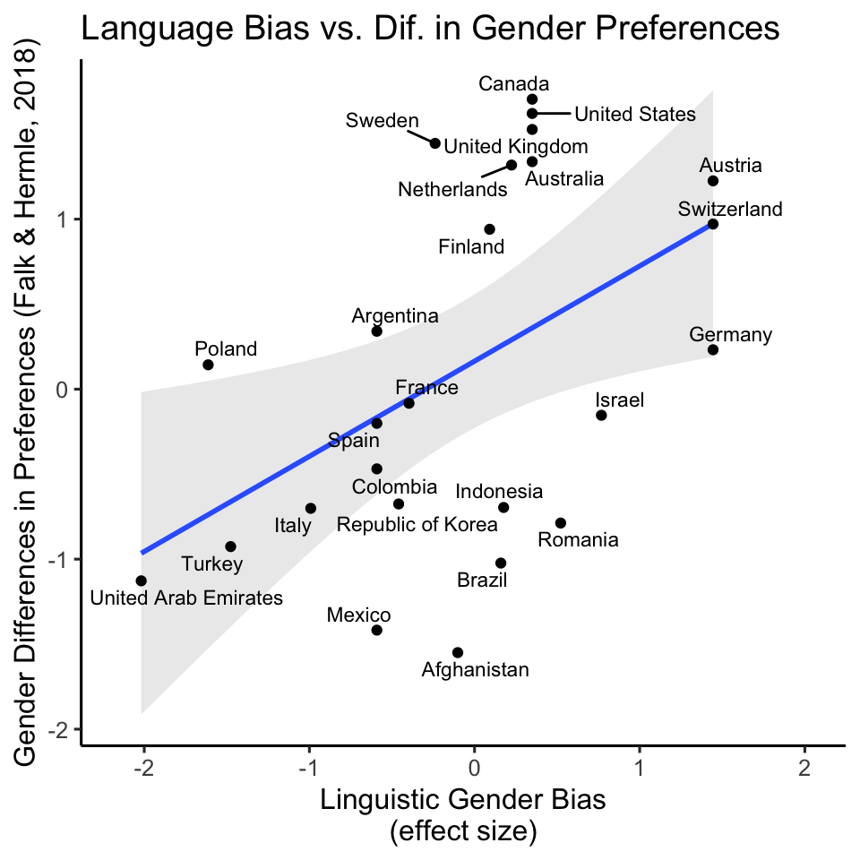

```r
country_level %>%
  ggplot(aes(x = lang_es_sub, y = genderdif, label = country))+
  ylab("Gender Differences in Preferences (Falk & Hermle, 2018)") +
  xlab("Linguistic Gender Bias\n(effect size)") +
  ggtitle("Language Bias vs. Dif. in Gender Preferences ") +
  geom_smooth(method = "lm", alpha = .2) +
  geom_point() +
  geom_text_repel(size = 3) +
  theme_classic(base_size = 12)
```

### Regressions

```r
lm(genderdif ~ gdp_2017 + lang_es_sub, data = country_level) %>%
  summary()
```

```
##
## Call:
## lm(formula = genderdif ~ gdp_2017 + lang_es_sub, data = country_level)
##
## Residuals:
##      Min       1Q   Median       3Q      Max
## -1.17914 -0.59741 -0.03639  0.46804  1.07196
##
## Coefficients:
##             Estimate Std. Error t value Pr(>|t|)
## (Intercept)   0.1414     0.1415   1.000 0.328369
## gdp_2017      0.7822     0.1774   4.410 0.000221 ***
## lang_es_sub   0.1850     0.1816   1.018 0.319613
## ---
## Signif. codes:  0 '***' 0.001 '**' 0.01 '*' 0.05 '.' 0.1 ' ' 1
##
## Residual standard error: 0.7041 on 22 degrees of freedom
##   (14 observations deleted due to missingness)
## Multiple R-squared:  0.5897, Adjusted R-squared:  0.5524
## F-statistic: 15.81 on 2 and 22 DF,  p-value: 5.55e-05
```

```r
lm(gdp_2017 ~ genderdif + lang_es_sub, data = country_level) %>%
  summary()
```

```
##
## Call:
## lm(formula = gdp_2017 ~ genderdif + lang_es_sub, data = country_level)
##
## Residuals:
##      Min       1Q   Median       3Q      Max
## -0.84924 -0.45747 -0.03692  0.26057  1.39747
##
## Coefficients:
##             Estimate Std. Error t value Pr(>|t|)
## (Intercept) -0.06919    0.12583  -0.550 0.587983
## genderdif    0.59992    0.13602   4.410 0.000221 ***
## lang_es_sub  0.14342    0.15988   0.897 0.379405
## ---
## Signif. codes:  0 '***' 0.001 '**' 0.01 '*' 0.05 '.' 0.1 ' ' 1
##
## Residual standard error: 0.6166 on 22 degrees of freedom
##   (14 observations deleted due to missingness)
## Multiple R-squared:  0.5855, Adjusted R-squared:  0.5478
## F-statistic: 15.54 on 2 and 22 DF,  p-value: 6.204e-05
```

### Mediation Models

```r
#psych::mediate(x = "lang_es_sub", y = "genderdif", m = "gdp_2017",
 #              data = country_level, plot = T) %>%
#  summary()
```

```r
#psych::mediate(x = "lang_es_sub", y = "gdp_2017", m = "genderdif",
#               data = country_level, plot = T) %>%
#  summary()

country_level %>%
  fit_mediation(
    x = "lang_es_sub",
    y = "per_women_stem",
    m = "genderdif") %>%
   test_mediation() %>%
   p_value()
```

```
## [1] 0.0206
```